# Regressão Linear múltipla - 3° Estágio - Exemplo Credit

Autor

Lucas Oliveira Belmiro - 118210068

Suelen Samara da Silva Felix - 121210333

# 1. Introdução

Este relatório tem como objetivo ajustar um modelo de regressão linear múltipla para investigar a influência de características específicas associadas ao comportamento dos consumidores na base de dados Credit. A regressão será realizada utilizando a base de dados Credit, que pode ser carregada a partir do pacote ISLR em R.

A base de dados Credit está disponível no pacote ISLR (Introduction to Statistical Learning with Applications in R), que é uma das referências principais em aprendizado estatístico e inclui diversas bases de dados para aplicação prática dos conceitos discutidos no livro.

Referência James, G., Witten, D., Hastie, T., & Tibshirani, R. (2013). An Introduction to Statistical Learning with Applications in R. Springer. Disponível em: https://www.statlearning.com/

### 1.1. Iniciando nossa base de dados

Após instalar as bibliotecas necessárias, vamos listar todas as variáveis da nossa base de dados Credit.

```r
install.packages("ISLR")
install.packages("corrplot")

library(corrplot)
library("ISLR")
library(dplyr)
library(knitr)
library(ggplot2)

data(Credit)
kable(Credit)
```

[output not shown]

[output cut: 347 more lines]

[output not shown]

# 2 . Descrevendo a base de dados

Nessa seção iremos analisar de maneira geral, os dados que foram fornecidas.

```r
str(Credit)
```

```
'data.frame':	400 obs. of  12 variables:
 $ ID       : int  1 2 3 4 5 6 7 8 9 10 ...
 $ Income   : num  14.9 106 104.6 148.9 55.9 ...
 $ Limit    : int  3606 6645 7075 9504 4897 8047 3388 7114 3300 6819 ...
 $ Rating   : int  283 483 514 681 357 569 259 512 266 491 ...
 $ Cards    : int  2 3 4 3 2 4 2 2 5 3 ...
 $ Age      : int  34 82 71 36 68 77 37 87 66 41 ...
 $ Education: int  11 15 11 11 16 10 12 9 13 19 ...
 $ Gender   : Factor w/ 2 levels " Male","Female": 1 2 1 2 1 1 2 1 2 2 ...
 $ Student  : Factor w/ 2 levels "No","Yes": 1 2 1 1 1 1 1 1 1 2 ...
 $ Married  : Factor w/ 2 levels "No","Yes": 2 2 1 1 2 1 1 1 1 2 ...
 $ Ethnicity: Factor w/ 3 levels "African American",..: 3 2 2 2 3 3 1 2 3 1 ...
 $ Balance  : int  333 903 580 964 331 1151 203 872 279 1350 ...
```

Como vemos pelo código acima, é possível notar que temos 400 observações e 12 variáveis, dentre elas, temos:

**ID**: Um identificador numérico único para cada uma das observações realizadas.

**Income**: Variável numérica contínua que representa a renda em dólares das pessoas.

**Limit**: Variável numérica, representada por números inteiros, que refere-se ao limite máximo de crédito de uma pessoa.

**Rating**: É a variável quantitativa que indica a pontuação de crédito, semelhante ao score no padrão brasileiro. Ou seja, quanto maior o rating, melhor a capacidade de crédito e confiança do indivíduo em cumprir com obrigações financeiras.

**Cards**: Variável quantitativa que indica o número de cartões de crédito em posse de cada pessoa.

**Age**: Variável quantitativa que indica a idade das pessoas em anos.

**Education**: É uma variável quantitativa que indica o nível de escolaridade dos indivíduos em anos.

**Gender**: Variável qualitativa que indica o gênero das pessoas, categorizado como "Male" (masculino) ou "Female" (feminino).

**Student**: Variável qualitativa que indica se a pessoa é estudante ou não, com valores "Yes" (sim) ou "No" (não).

**Married**: Variável qualitativa que indica quando uma pessoa é casada, com valores "Yes" (casado) ou "No" (não casado).

**Ethnicity**: Variável qualitativa que indica a etnia das observações.

**Balance**: É uma variável quantitativa que indica o saldo devido das pessoas, em dólares.

# 3. Análise exploratória dos dados, outliers e correções na base de dados. Iniciaremos limpando a base de dados, removendo a coluna ID que não será utilizada durante o restante deste trabalho.

```r
# Filtrar o conjunto de dados excluindo a coluna "ID"
df <- Credit %>%
  select(-ID) %>%
  transmute(renda = Income,
            limite = Limit,
            score = Rating,
            cartoes = Cards,
            idade = Age,
            educacao = Education,
            genero = Gender,
            estudante = Student,
            casado = Married,
            etnia = Ethnicity,
            saldo = Balance)
```

Para realizar uma análise exploratória de dados, iremos verificar também se existem valores ausentes no nosso dataframe e de outliers.

```r
# Verifica possíveis valores ausentes
colSums(is.na(Credit))
```

**ID**

0

**Income**

0

**Limit**

0

**Rating**

0

**Cards**

0

**Age**

0

**Education**

0

**Gender**

0

**Student**

0

**Married**

0

**Ethnicity**

0

**Balance**

0

```r
install.packages("skimr", dependencies = TRUE)
library(skimr)

dados <-  Credit %>%
  select(-ID) %>%
  transmute(renda = Income,
            limite = Limit,
            score = Rating,
            saldo = Balance,
            cartoes = Cards,
            idade = Age,
            educacao = Education,
            genero = Gender,
            estudante = Student,
            casado = Married,
            etnia = Ethnicity)
skim(dados)
```

Data summary

| Name | dados |
| --- | --- |
| Number of rows | 400 |
| Number of columns | 11 |
| _______________________ |  |
| Column type frequency: |  |
| factor | 4 |
| numeric | 7 |
| ________________________ |  |
| Group variables | None |

**Variable type: factor**

[output not shown]

**Variable type: numeric**

| skim_variable | n_missing | complete_rate | mean | sd | p0 | p25 | p50 | p75 | p100 | hist |
| --- | --- | --- | --- | --- | --- | --- | --- | --- | --- | --- |
| renda | 0 | 1 | 45.2 | 35.2 | 10.4 | 21.0 | 33.1 | 57.5 | 187 | ▇▂▁▁▁ |
| limite | 0 | 1 | 4736 | 2308 | 855 | 3088 | 4622 | 5873 | 13913 | ▆▇▃▁▁ |
| score | 0 | 1 | 355 | 155 | 93 | 247 | 344 | 437 | 982 | ▆▇▃▁▁ |
| saldo | 0 | 1 | 520 | 460 | 0 | 68,8 | 460 | 863 | 1999 | ▇▅▃▂▁ |
| cartoes | 0 | 1 | 2,96 | 1,37 | 1 | 2 | 3 | 4 | 9 | ▇▇▂▁▁ |
| idade | 0 | 1 | 55,7 | 17,2 | 23 | 41,8 | 56 | 70 | 98 | ▆▇▇▇▁ |
| educacao | 0 | 1 | 13,4 | 3,13 | 5 | 11 | 14 | 16 | 20 | ▂▅▇▇▂ |

# 3.1 Análise de correlação

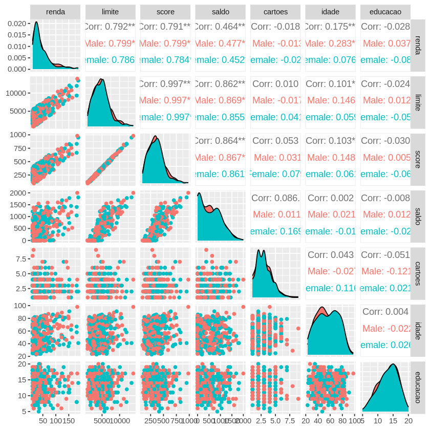

```r
install.packages("GGally")
library(GGally)


### Multicolinearidade: r > 0.9 (ou 0.8)

graf1 <- ggpairs(dados, columns = 1:7, ggplot2::aes(colour=genero))

graf1
```

Através desses gráficos, podemos analisar a correlação com a variável resposta Balance (Saldo) e temos que:

- Renda:

  Apresenta uma correlação significativa de 0,464*** com saldo. Isso indica uma relação positiva moderada, sugerindo que à medida que a renda aumenta, o saldo tende a aumentar também.
- Limite:

  Tem uma correlação forte de 0,862*** com saldo, o que sugere que um limite maior está associado a um saldo mais elevado. Isso pode ser esperado, pois um maior limite de crédito pode proporcionar mais oportunidades de gastos e, consequentemente, um saldo mais elevado.
- Score:

  A correlação entre "saldo" e "score" é de 0,864***. Isso indica que scores de crédito mais altos estão associados a saldos mais altos, reforçando a ideia de que consumidores com melhor crédito tendem a ter melhores condições financeiras.
- Cartões:

  A correlação entre o número de cartões e o saldo é baixa, em torno de 0.086. Isso indica que o número de cartões de crédito de uma pessoa tem pouca influência direta sobre o saldo mantido.
- Idade:

# 4. Análises univariadas e bivariadas

```
     renda            limite          score           saldo
 Min.   : 10.35   Min.   :  855   Min.   : 93.0   Min.   :   0.00
 1st Qu.: 21.01   1st Qu.: 3088   1st Qu.:247.2   1st Qu.:  68.75
 Median : 33.12   Median : 4622   Median :344.0   Median : 459.50
 Mean   : 45.22   Mean   : 4736   Mean   :354.9   Mean   : 520.01
 3rd Qu.: 57.47   3rd Qu.: 5873   3rd Qu.:437.2   3rd Qu.: 863.00
 Max.   :186.63   Max.   :13913   Max.   :982.0   Max.   :1999.00
    cartoes          idade          educacao        genero    estudante
 Min.   :1.000   Min.   :23.00   Min.   : 5.00    Male :193   No :360
 1st Qu.:2.000   1st Qu.:41.75   1st Qu.:11.00   Female:207   Yes: 40
 Median :3.000   Median :56.00   Median :14.00
 Mean   :2.958   Mean   :55.67   Mean   :13.45
 3rd Qu.:4.000   3rd Qu.:70.00   3rd Qu.:16.00
 Max.   :9.000   Max.   :98.00   Max.   :20.00
 casado                 etnia
 No :155   African American: 99
 Yes:245   Asian           :102
           Caucasian       :199
```

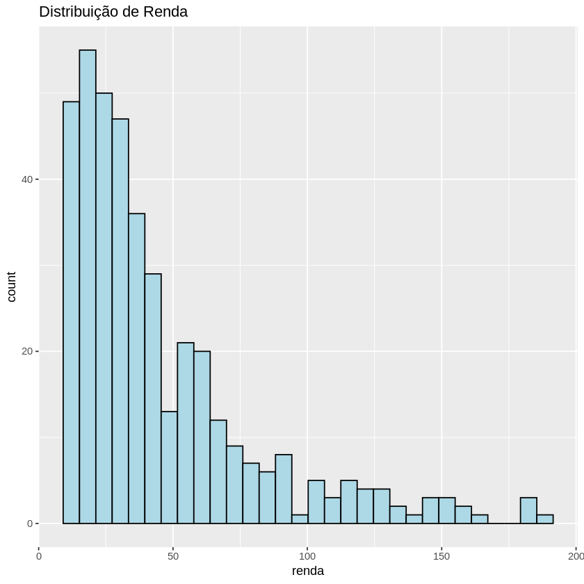

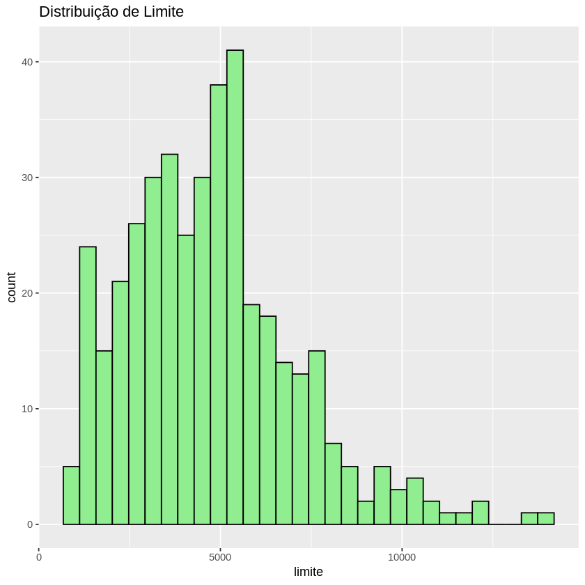

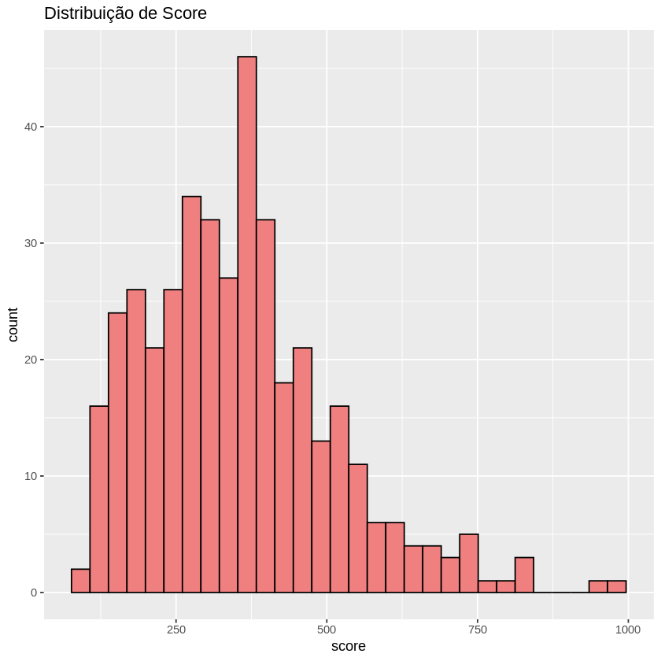

```
              renda     limite      score     cartoes      saldo
renda    1.00000000 0.79208834 0.79137763 -0.01827261 0.46365646
limite   0.79208834 1.00000000 0.99687974  0.01023133 0.86169727
score    0.79137763 0.99687974 1.00000000  0.05323903 0.86362516
cartoes -0.01827261 0.01023133 0.05323903  1.00000000 0.08645635
saldo    0.46365646 0.86169727 0.86362516  0.08645635 1.00000000
```

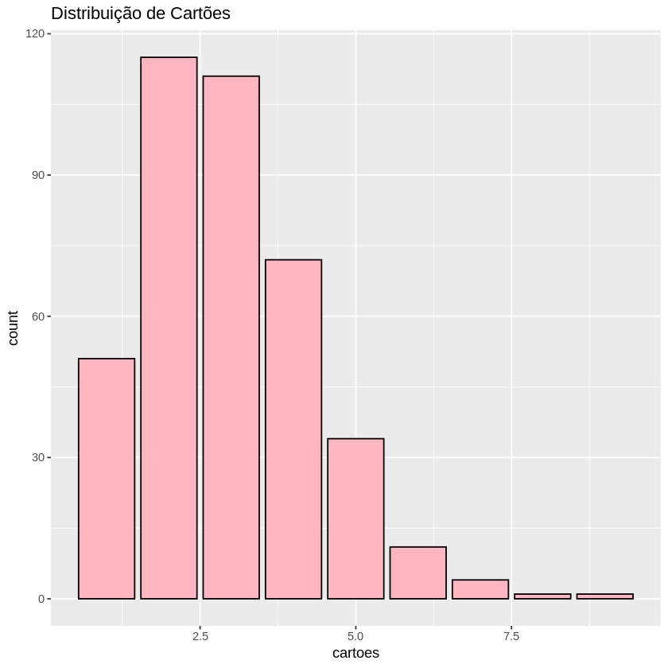

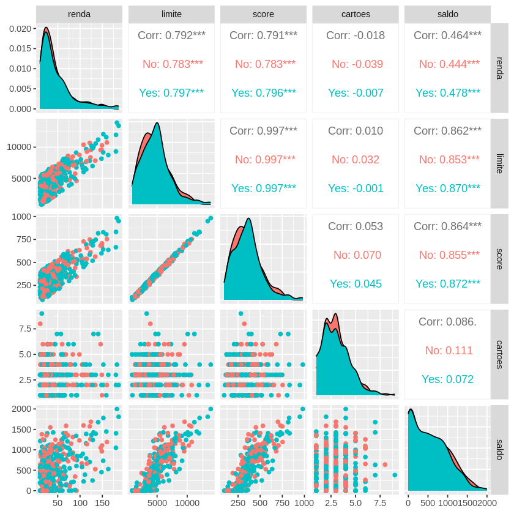

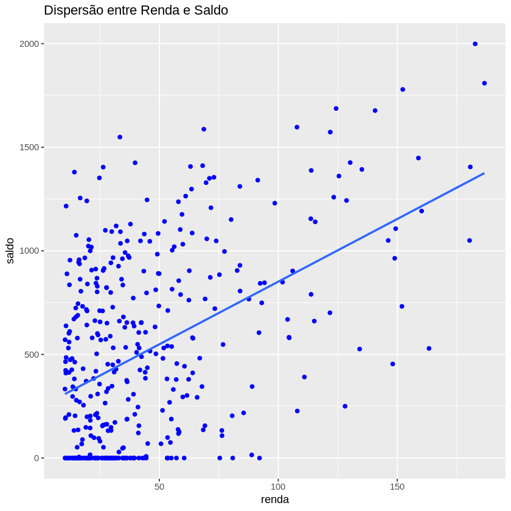

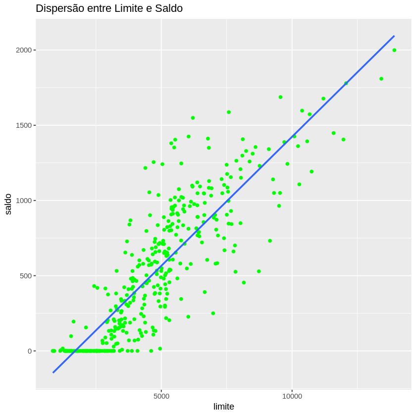

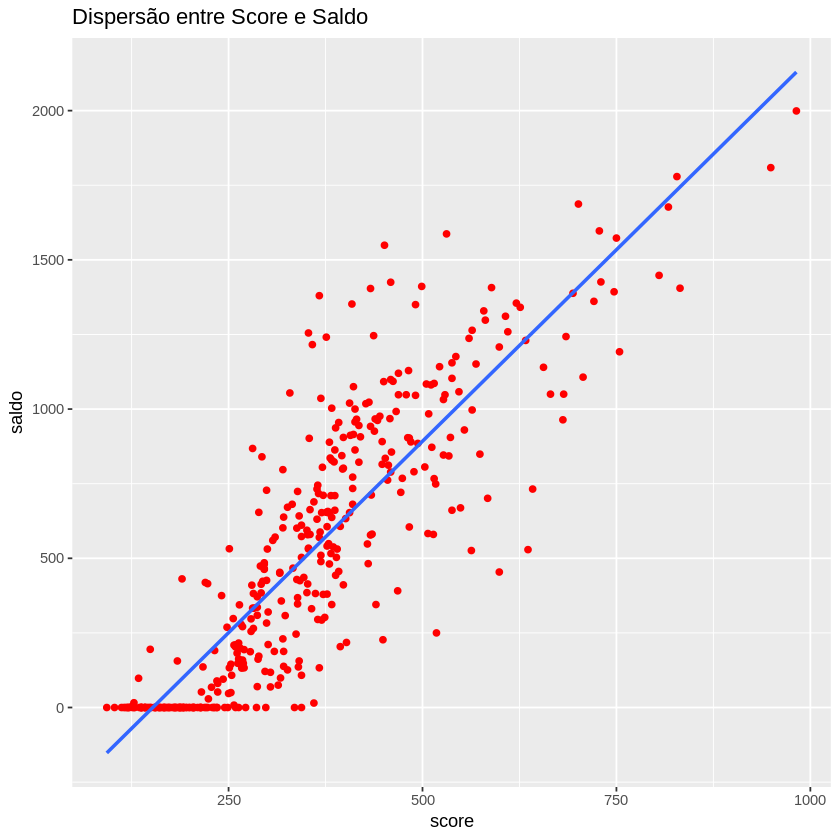

```
	Pearson's product-moment correlation

data:  dados$renda and dados$saldo
t = 10.44, df = 398, p-value < 2.2e-16
alternative hypothesis: true correlation is not equal to 0
95 percent confidence interval:
 0.3830176 0.5372821
sample estimates:
      cor
0.4636565


	Pearson's product-moment correlation

data:  dados$limite and dados$saldo
t = 33.879, df = 398, p-value < 2.2e-16
alternative hypothesis: true correlation is not equal to 0
95 percent confidence interval:
 0.8341212 0.8849765
sample estimates:
      cor
0.8616973


	Pearson's product-moment correlation

data:  dados$score and dados$saldo
t = 34.176, df = 398, p-value < 2.2e-16
alternative hypothesis: true correlation is not equal to 0
95 percent confidence interval:
 0.8363997 0.8865997
sample estimates:
      cor
0.8636252


	Pearson's product-moment correlation

data:  dados$cartoes and dados$saldo
t = 1.7313, df = 398, p-value = 0.08418
alternative hypothesis: true correlation is not equal to 0
95 percent confidence interval:
 -0.01169451  0.18295710
sample estimates:
       cor
0.08645635

     renda     limite      score    cartoes
  2.702816 227.829464 229.587751   1.431425
```

'Atenção: Pode haver multicolinearidade!'

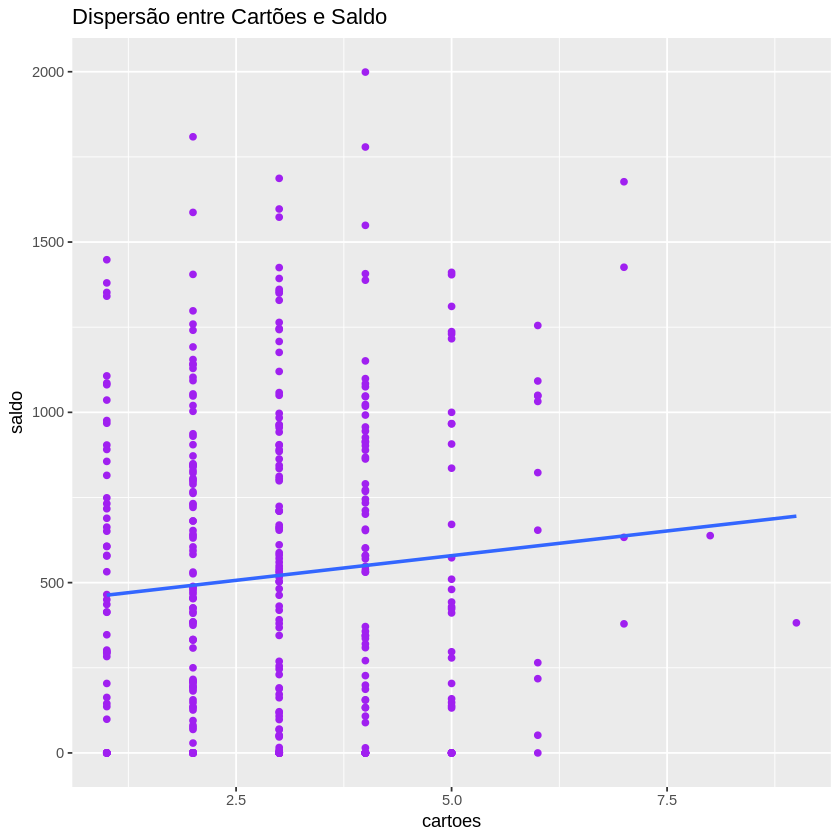

```r
install.packages("car")
library(GGally)
library(ggplot2)
library(dplyr)
library(car)


# Análise Univariada
# Estatísticas descritivas
summary(dados)

# Visualização das distribuições
ggplot(dados, aes(x = renda)) +
  geom_histogram(bins = 30, fill = "lightblue", color = "black") +
  ggtitle("Distribuição de Renda")

ggplot(dados, aes(x = limite)) +
  geom_histogram(bins = 30, fill = "lightgreen", color = "black") +
  ggtitle("Distribuição de Limite")

ggplot(dados, aes(x = score)) +
  geom_histogram(bins = 30, fill = "lightcoral", color = "black") +
  ggtitle("Distribuição de Score")

ggplot(dados, aes(x = cartoes)) +
  geom_bar(fill = "lightpink", color = "black") +
  ggtitle("Distribuição de Cartões")

# Análise Bivariada
# Matriz de correlação
cor_matrix <- cor(dados[, c("renda", "limite", "score", "cartoes", "saldo")])
print(cor_matrix)

# Gráficos de dispersão e correlação
ggpairs(dados, columns = c("renda", "limite", "score", "cartoes", "saldo"),
        aes(colour = casado))

# Gráficos de dispersão específicos
ggplot(dados, aes(x = renda, y = saldo)) +
  geom_point(color = "blue") +
  geom_smooth(method = "lm", se = FALSE) +
  ggtitle("Dispersão entre Renda e Saldo")

ggplot(dados, aes(x = limite, y = saldo)) +
  geom_point(color = "green") +
  geom_smooth(method = "lm", se = FALSE) +
  ggtitle("Dispersão entre Limite e Saldo")

ggplot(dados, aes(x = score, y = saldo)) +
  geom_point(color = "red") +
  geom_smooth(method = "lm", se = FALSE) +
  ggtitle("Dispersão entre Score e Saldo")

ggplot(dados, aes(x = cartoes, y = saldo)) +
  geom_point(color = "purple") +
  geom_smooth(method = "lm", se = FALSE) +
  ggtitle("Dispersão entre Cartões e Saldo")

# Modelo de regressão linear
modelo <- lm(saldo ~ renda + limite + score + cartoes, data = dados)
# Exibir resultados de correlação de Pearson
cor_results_renda <- cor.test(dados$renda, dados$saldo)
print(cor_results_renda)

cor_results_limite <- cor.test(dados$limite, dados$saldo)
print(cor_results_limite)

cor_results_score <- cor.test(dados$score, dados$saldo)
print(cor_results_score)

cor_results_cartoes <- cor.test(dados$cartoes, dados$saldo)
print(cor_results_cartoes)

vif_results <- vif(modelo)
print(vif_results)

# Interpretação dos resultados de VIF
ifelse(any(vif_results > 10), "Atenção: Pode haver multicolinearidade!", "Não há problemas de multicolinearidade significativos.")
```

# 4.1. Análise Univariada

# 4.2. Análise Bivariada

A matriz de correlação revelou o seguinte:

- Renda e Saldo: A correlação é positiva, mas não muito alta, sugerindo que aumentos na renda estão associados a aumentos no saldo, mas outros fatores também influenciam essa relação.
- Limite e Saldo: Apresenta uma correlação forte e positiva, indicando que limites maiores tendem a estar associados a saldos maiores.
- Score e Saldo: A correlação é moderadamente alta, sugerindo que scores melhores estão associados a saldos mais elevados.
- Cartões e Saldo: A correlação é baixa, indicando que o número de cartões não tem uma relação significativa com o saldo.

Os gráficos de dispersão (exibindo a relação entre cartões e saldo) mostram uma tendência geral de aumento, mas com muitos outliers e dispersão, o que reforça a baixa correlação observada.

# 4.3. VIF e Multicolinearidade

A mensagem de alerta sobre a multicolinearidade indica que as conclusões tiradas a partir do modelo de regressão linear devem ser interpretadas com cautela. É recomendável considerar a exclusão de variáveis altamente correlacionadas ou a aplicação de técnicas de regularização para resolver esses problemas.

# 4.4. Teste de Correlação de Pearson

São realizados testes de correlação de Pearson entre cada variável explicativa e a variável resposta (saldo). Isso fornece insights sobre a força e a direção da relação linear entre as variáveis.

Dessa forma, o coeficiente de correlação de Pearson pode ser classificado das seguintes formas:

- Correlação menor que zero: Se a correlação for menor que zero, significa que é negativo, isto é, que as variáveis são inversamente relacionadas. Quando o valor de alguma variável é alto, o valor da outra variável é baixo.
- Correlação maior que zero: Quando a correlação é maior que zero, significa que a correlação é positiva, isto é, que as variáveis estão diretamente correlacionadas. Quando o valor de uma variável é alto, o valor da outra variável também é alto, o mesmo acontece quando eles são baixos.
- Correlação igual a zero: Quando a correlação é igual a zero, significa que não é possível determinar qualquer senso de covariação.
- Correlação igual a +1 ou -1: Quando a correlação é igual a +1 ou -1, significa uma correlação positiva perfeita ou uma correlação negativa perfeita, respectivamente.

Adicionalmente, ainda podemos classificar o coeficiente de correlação de três maneiras, de acordo com o intervalo no qual o coeficiente está contido:

- Correlação entre 0 e 0,3: Quando o módulo da correlação está entre 0 e 0,3, isso sugere uma relação linear fraca entre as variáveis. Embora exista uma associação, ela é bastante limitada.
- Correlação entre 0,3 e 0,7: Quando o módulo da correlação está entre 0,3 e 0,7, indica uma relação linear moderada entre as variáveis. Nesse caso, as variáveis tendem a se mover juntas em certa medida, mas não de forma extremamente forte.
- Correlação entre 0,7 e 1: Quando o módulo da correlação é maior ou igual a 0,7, indica uma forte relação linear entre as variáveis. Isso significa que as variáveis estão altamente correlacionadas e tendem a se mover juntas de forma consistente. Essa forte associação pode ser útil para prever ou explicar o comportamento das variáveis dependentes com base nos valores das variáveis independentes.

# 4.5. Conclusão

A análise univariada e bivariada forneceu insights valiosos sobre as relações entre variáveis explicativas e a variável resposta Balance (saldo). A presença de multicolinearidade sugere que uma investigação adicional ou ajustes ao modelo são necessários para obter interpretações precisas.

# 5. Ajustando o modelo inicial cosiderando todas as variáveis explicativas

```
Call:
lm(formula = saldo ~ renda + limite + score + cartoes + idade +
    educacao + genero + casado + etnia, data = dados)

Residuals:
    Min      1Q  Median      3Q     Max
-214.80 -110.36  -46.20   51.76  530.73

Coefficients:
                 Estimate Std. Error t value Pr(>|t|)
(Intercept)    -478.49892   58.38617  -8.195 3.65e-15 ***
renda            -7.55003    0.38194 -19.767  < 2e-16 ***
limite            0.11114    0.05325   2.087  0.03754 *
score             2.28874    0.79777   2.869  0.00434 **
cartoes          10.40326    7.06938   1.472  0.14194
idade            -0.92453    0.47940  -1.929  0.05452 .
educacao          2.22610    2.59927   0.856  0.39229
generoFemale      3.52732   16.15496   0.218  0.82728
casadoYes       -34.43100   16.83144  -2.046  0.04146 *
etniaAsian       32.11041   23.02264   1.395  0.16389
etniaCaucasian    6.21498   19.92610   0.312  0.75528
---
Signif. codes:  0 ‘***’ 0.001 ‘**’ 0.01 ‘*’ 0.05 ‘.’ 0.1 ‘ ’ 1

Residual standard error: 161.2 on 389 degrees of freedom
Multiple R-squared:  0.8801,	Adjusted R-squared:  0.877
F-statistic: 285.5 on 10 and 389 DF,  p-value: < 2.2e-16
```

```
Teste de Shapiro-Wilk para normalidade dos resíduos:

	Shapiro-Wilk normality test

data:  residuals(modelo_inicial)
W = 0.87287, p-value < 2.2e-16

Teste de Breusch-Pagan para homocedasticidade:

	studentized Breusch-Pagan test

data:  modelo_inicial
BP = 12.636, df = 10, p-value = 0.2447
```

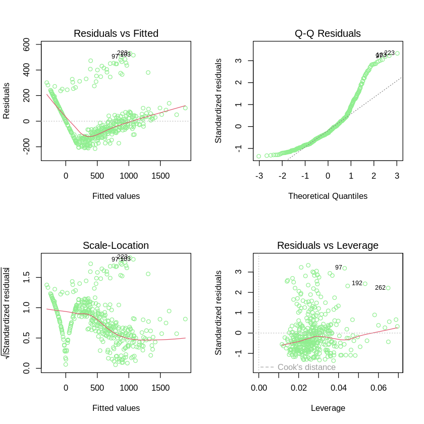

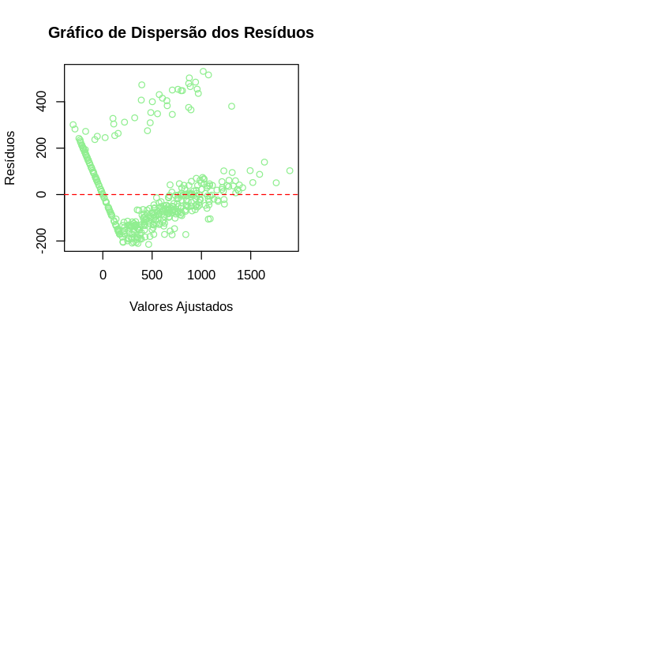

```r
install.packages('lmtest', repos = 'http://cran.us.r-project.org')
# Ajustar o modelo inicial
modelo_inicial <- lm(saldo ~ renda + limite + score + cartoes + idade + educacao + genero + casado + etnia, data = dados)

# Resumo do modelo
summary(modelo_inicial)

# Análise dos resíduos
par(mfrow=c(2, 2)) # Configuração do layout do gráfico
plot(modelo_inicial, which = 1, col = "lightgreen") # Histograma dos resíduos
plot(modelo_inicial, which = 2, col = "lightgreen") # Gráfico QQ plot dos resíduos
plot(modelo_inicial, which = 3, col = "lightgreen") # Resíduos vs. Valores Ajustados
plot(modelo_inicial, which = 5, col = "lightgreen") # Resíduos vs. Variáveis Explicativas

# Gráfico de Dispersão dos Resíduos
residuos <- resid(modelo_inicial)
valores_ajustados <- fitted(modelo_inicial)
plot(valores_ajustados, residuos, main = "Gráfico de Dispersão dos Resíduos",
     xlab = "Valores Ajustados", ylab = "Resíduos", col = "lightgreen")
abline(h = 0, col = "red", lty = 2) # Adiciona linha horizontal em y=0

# Teste de normalidade dos resíduos
shapiro_test <- shapiro.test(residuals(modelo_inicial))
cat("Teste de Shapiro-Wilk para normalidade dos resíduos:\n")
print(shapiro_test)

# Teste de homocedasticidade
library(lmtest)
bptest_result <- bptest(modelo_inicial)
cat("Teste de Breusch-Pagan para homocedasticidade:\n")
print(bptest_result)
```

# Gráficos de Diagnóstico

Os gráficos de diagnóstico fornecem informações importantes sobre a qualidade do ajuste do modelo de regressão linear. Vamos analisar cada um deles:

1. Residuals vs Fitted:

4. Residuals vs Leverage:

Padrão: Há alguns pontos com alta alavancagem, mas nenhum parece influenciar significativamente os resultados.

# 6. Escolhendo o melhor modelo

```r
# Ajustando vários modelos
modelo_1 <- lm(saldo ~ renda + limite, data = dados)
modelo_2 <- lm(saldo ~ renda + limite + score, data = dados)
modelo_3 <- lm(saldo ~ renda + limite + score + cartoes + idade, data = dados)

# Resumos dos modelos
summary(modelo_1)
summary(modelo_2)
summary(modelo_3)

# Comparando AIC e BIC
aic_values <- c(AIC(modelo_1), AIC(modelo_2), AIC(modelo_3))
bic_values <- c(BIC(modelo_1), BIC(modelo_2), BIC(modelo_3))

cat("AIC dos modelos:\n", aic_values, "\n")
cat("BIC dos modelos:\n", bic_values, "\n")
```

```
Call:
lm(formula = saldo ~ renda + limite, data = dados)

Residuals:
    Min      1Q  Median      3Q     Max
-232.79 -115.45  -48.20   53.36  549.77

Coefficients:
              Estimate Std. Error t value Pr(>|t|)
(Intercept) -385.17926   19.46480  -19.79   <2e-16 ***
renda         -7.66332    0.38507  -19.90   <2e-16 ***
limite         0.26432    0.00588   44.95   <2e-16 ***
---
Signif. codes:  0 ‘***’ 0.001 ‘**’ 0.01 ‘*’ 0.05 ‘.’ 0.1 ‘ ’ 1

Residual standard error: 165.5 on 397 degrees of freedom
Multiple R-squared:  0.8711,	Adjusted R-squared:  0.8705
F-statistic:  1342 on 2 and 397 DF,  p-value: < 2.2e-16
```

```
Call:
lm(formula = saldo ~ renda + limite + score, data = dados)

Residuals:
    Min      1Q  Median      3Q     Max
-260.93 -113.14  -36.27   49.35  554.23

Coefficients:
              Estimate Std. Error t value Pr(>|t|)
(Intercept) -489.72748   32.09892 -15.257  < 2e-16 ***
renda         -7.71931    0.37806 -20.418  < 2e-16 ***
limite         0.08467    0.04471   1.894    0.059 .
score          2.69858    0.66594   4.052 6.11e-05 ***
---
Signif. codes:  0 ‘***’ 0.001 ‘**’ 0.01 ‘*’ 0.05 ‘.’ 0.1 ‘ ’ 1

Residual standard error: 162.4 on 396 degrees of freedom
Multiple R-squared:  0.8762,	Adjusted R-squared:  0.8753
F-statistic: 934.6 on 3 and 396 DF,  p-value: < 2.2e-16
```

```
Call:
lm(formula = saldo ~ renda + limite + score + cartoes + idade,
    data = dados)

Residuals:
    Min      1Q  Median      3Q     Max
-231.37 -113.46  -39.55   41.66  544.35

Coefficients:
              Estimate Std. Error t value Pr(>|t|)
(Intercept) -449.36101   40.57409 -11.075   <2e-16 ***
renda         -7.56211    0.38214 -19.789   <2e-16 ***
limite         0.12855    0.05289   2.430   0.0155 *
score          2.02240    0.79208   2.553   0.0110 *
cartoes       11.55272    7.06285   1.636   0.1027
idade         -0.88832    0.47781  -1.859   0.0638 .
---
Signif. codes:  0 ‘***’ 0.001 ‘**’ 0.01 ‘*’ 0.05 ‘.’ 0.1 ‘ ’ 1

Residual standard error: 161.6 on 394 degrees of freedom
Multiple R-squared:  0.8781,	Adjusted R-squared:  0.8765
F-statistic: 567.4 on 5 and 394 DF,  p-value: < 2.2e-16
```

```
AIC dos modelos:
 5227.203 5212.95 5211.013
BIC dos modelos:
 5243.168 5232.908 5238.954
```

# AIC e BIC dos Modelos

**Modelo 1 (saldo ~ renda + limite)**:

AIC: 5227.203 BIC: 5243.168

**Modelo 2 (saldo ~ renda + limite + score)**:

AIC: 5212.95 BIC: 5232.908

**Modelo 3 (saldo ~ renda + limite + score + cartoes + idade)**:

AIC: 5211.013 BIC: 5238.954

# 6.1. Análise dos Resultados

- AIC (Akaike Information Criterion):

# Interpretação:

# 7. Pressupostos do MRLM

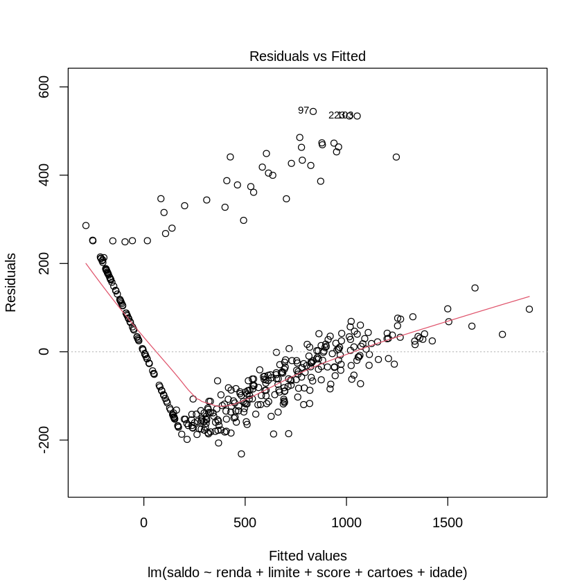

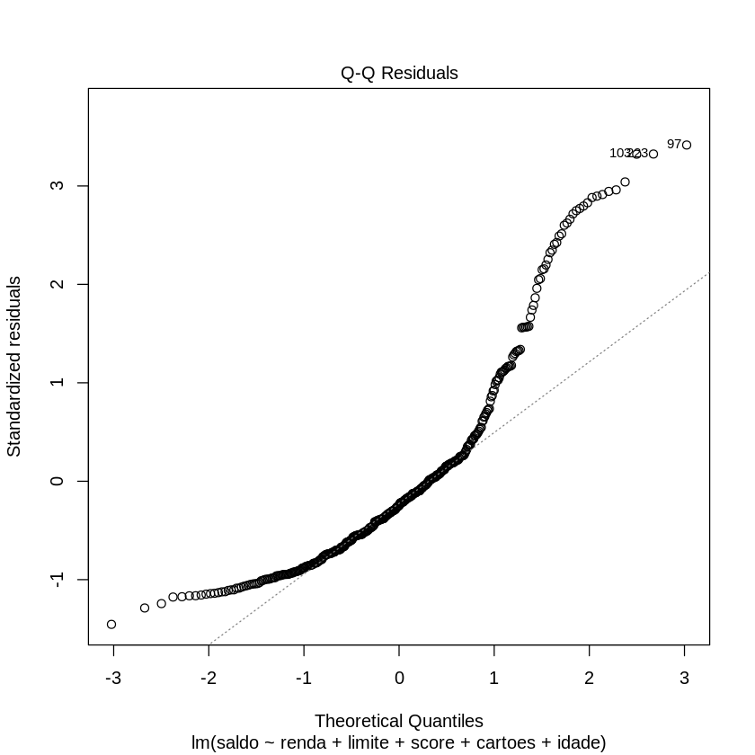

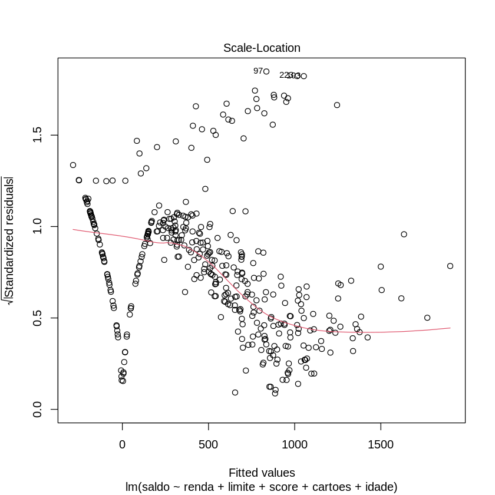

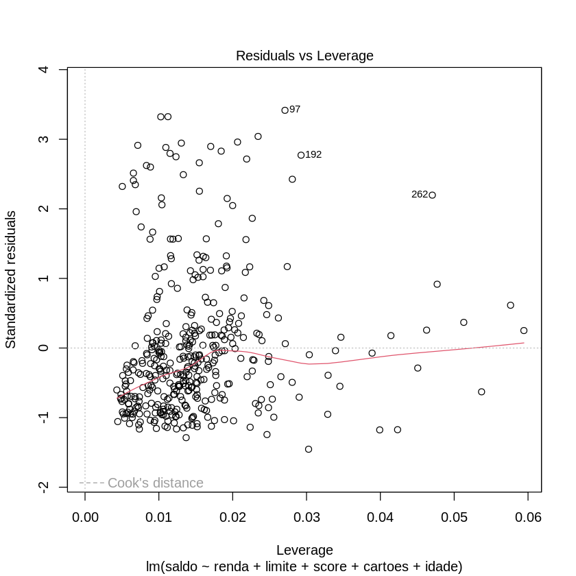

```r
install.packages("report")
plot(modelo_3)

library(report)
report(modelo_3)
```

# Tradução da função report(modelo_3):

Ajustamos um modelo linear (estimado usando OLS) para prever equilíbrio com renda, limite, score, cartoes e idade (fórmula: saldo ~ renda + limite + score + cartoes + idade). O modelo explica uma proporção estatisticamente significativa e substancial da variância (R2 = 0,88, F(5, 394) = 567,43, p < 0,001, R2 adj. = 0,88). O intercepto do modelo, correspondente a renda = 0, limite = 0, score = 0, cartoes = 0 e idade = 0, está em -449,36 (IC 95% [-529,13, -369,59], t(394) = -11,08, p < 0,001).

Dentro deste modelo:

- O efeito de renda é estatisticamente significativo e negativo (beta = -7,56, IC 95% [-8,31, -6,81], t(394) = -19,79, p < 0,001; beta padrão = -0,58, IC 95% [-0,64, -0,52])
- O efeito de limite é estatisticamente significativo e positivo (beta = 0,13, IC 95% [0,02, 0,23], t(394) = 2,43, p = 0,016; beta padrão = 0,65, IC 95% [0,12, 1,17])
- O efeito de pontuação (score) é estatisticamente significativo e positivo (beta = 2,02, IC 95% [0,47, 3,58], t(394) = 2,55, p = 0,011; beta padrão = 0,68, IC 95% [0,16, 1,20])
- O efeito dos cartoes é estatisticamente não significativo e positivo (beta = 11,55, IC 95% [-2,33, 25,44], t(394) = 1,64, p = 0,103; beta padrão = 0,03, IC 95% [-6,96e-03, 0,08])
- O efeito da idade é estatisticamente não significativo e negativo (beta = -0,89, IC 95% [-1,83, 0,05], t(394) = -1,86, p = 0,064; beta padrão = -0,03, IC 95% [-0,07, 1.92e-03])

Os parâmetros padronizados foram obtidos ajustando o modelo em uma versão padronizada do conjunto de dados. Intervalos de confiança (ICs) de 95% e valores de p foram calculados usando uma aproximação de distribuição t de Wald.

# 8. Previsões

```r
summary(modelo_3)
```

```
Call:
lm(formula = saldo ~ renda + limite + score + cartoes + idade,
    data = dados)

Residuals:
    Min      1Q  Median      3Q     Max
-231.37 -113.46  -39.55   41.66  544.35

Coefficients:
              Estimate Std. Error t value Pr(>|t|)
(Intercept) -449.36101   40.57409 -11.075   <2e-16 ***
renda         -7.56211    0.38214 -19.789   <2e-16 ***
limite         0.12855    0.05289   2.430   0.0155 *
score          2.02240    0.79208   2.553   0.0110 *
cartoes       11.55272    7.06285   1.636   0.1027
idade         -0.88832    0.47781  -1.859   0.0638 .
---
Signif. codes:  0 ‘***’ 0.001 ‘**’ 0.01 ‘*’ 0.05 ‘.’ 0.1 ‘ ’ 1

Residual standard error: 161.6 on 394 degrees of freedom
Multiple R-squared:  0.8781,	Adjusted R-squared:  0.8765
F-statistic: 567.4 on 5 and 394 DF,  p-value: < 2.2e-16
```

```r
# Criando um novo data frame com as médias das variáveis explicativas
novas.preditoras <- data.frame(
  renda = c(14.9, 104.6),
  limite = c(3606, 7075),
  score = c(283, 514),
  cartoes = c(1, 4),
  idade = c(18, 82)
)

# Previsão pontual
predict <- predict(modelo_3, novas.preditoras, interval = "confidence")
print(predict)
```

```
       fit      lwr      upr
1 469.4303 420.0009 518.8597
2 682.0419 642.2053 721.8785
```

- Estimativas Pontuais (fit):
  - A estimativa pontual do saldo para a primeira observação é 469.43. Isso significa que, com base nas variáveis explicativas utilizadas, espera-se que o saldo médio seja de aproximadamente 469.43.
  - Para a segunda observação, a estimativa pontual é 682.04. Este valor reflete a previsão média do saldo dado o conjunto de variáveis explicativas especificadas para essa observação.
- Intervalos de Confiança (lwr e upr):
  - O intervalo de confiança para a primeira previsão varia entre 420.00 e 518.86. Isso indica que estamos 95% confiantes de que a média do saldo real (considerando o mesmo conjunto de variáveis) estará entre esses dois valores. A amplitude relativamente estreita sugere uma boa precisão na estimativa. *Para a segunda previsão, o intervalo de confiança se estende de 642.21 a 721.88. Novamente, isso indica um alto nível de confiança de que a média do saldo real estará dentro desse intervalo.